# Projet n°3 - Concevez une application au service de la santé publique

## Partie 2 - Exploration

### Hypothèses

La consommation de sucre max journalière d'après l'OMS = 50g. Les goûters proposés dans les distributeurs peuvent être respondable d'une grand part de notre consomation de sucre. Un goûter = un snack sucré et une boisson.

L'exploration des données sera axée sur les snacks et les boissons.

### Sommaire

**1.** Importation des données

- 1.1 Application à ***snack_control***, Machine SELECTA
- 1.2 Création de df_SNACK

**2.** Analyses univariées

- 2.1 Variables quantitatives
- 2.2 Variables catégorielles

**3.** Analyses bivariées

- 3.1 Variables quantitatives vs variables quantitatives
- 3.2 Variables qualitatives vs variables qualitatives
- 3.3 Variables quantitatives vs variables qualitatives

**4.** Analyses multivariées

```python
import pandas as pd
import numpy as np
import scipy.stats as stats
import matplotlib.pyplot as plt
import seaborn as sns
import missingno as msno
import clean #mon module de fontions qui me permettent de nettoyer un dataframe
import plot_ #mon module de plotting
import stat_ #mon module de stat.

# Filter warnings
import warnings
warnings.filterwarnings('ignore')
```

# 1. Importation des données

Importation de la base de donnée open food facts, "nettoyée".

```python
df = pd.read_csv('df_clean_fKnn.csv',
                 dtype={'NOVA_GROUP': 'object',
                        'NUTRISCORE_GRADE': 'object',
                        'CODE':'object',
                        'GROUPE':'category'})
```

```python
df = df.rename(columns = {'PRODUCT_NAME':'PRODUIT',
                         'PNNS_GROUPS_1': 'GROUPE',
                         'SUGARS_100G' : 'SUCRES_100G',
                         'SATURATED-FAT_100G': 'GRAS-SAT_100G',
                         'FIBER_100G': 'FIBRES_100G',
                         'SALT_100G':'SEL_100G',
                         'ADDITIVES_N' : 'NB_ADDITIFS',
                         'ENERGY-KCAL_100G': 'ENERGIE-KCAL_100G',
                         'CARBOHYDRATES_100G' : 'GLUCIDES_100G',
                         'PROTEINS_100G': 'PROTÉINES_100G'})



#df = df[(df['GROUPE']== 'Sucreries')|
      #(df['GROUPE']== 'Boissons')]
#df['GROUPE'] =  df['GROUPE'].astype('category')
```

```python
df.head()
```

|  | CODE | URL | PRODUIT | GROUPE | INGREDIENTS_TEXT | SUCRES_100G | GRAS-SAT_100G | FIBRES_100G | SEL_100G | NB_ADDITIFS | ENERGIE-KCAL_100G | GLUCIDES_100G | PROTÉINES_100G | NOVA_GROUP | NUTRISCORE_GRADE | NB_NAN |
| --- | --- | --- | --- | --- | --- | --- | --- | --- | --- | --- | --- | --- | --- | --- | --- | --- |
| 0 | 8003007816546 | https://world.openfoodfacts.org/product/800300... | TUBETTINI INTEGRALI | Céréales et pomme de terre | SEMOULE COMPLÈTE DE BLE DUR ET EAU | 6.8 | 0.10 | 6.7 | 0.02 | 0.0 | 362.0 | 75.0 | 15.0 | 1 | a | 0 |
| 1 | 3258563461548 | https://world.openfoodfacts.org/product/325856... | TRIPES À LA | Viandes | ESTOMACS ET PIEDS DE BŒUF 77%, FOND DE SAUCE :... | 0.5 | 1.50 | 1.0 | 1.10 | 0.0 | 109.0 | 0.5 | 20.0 | 3 | b | 0 |
| 2 | 3760017370011 | https://world.openfoodfacts.org/product/376001... | POUSSES DE HARICOT | Céréales et pomme de terre | POUSSES DE HARICOT MUNGO | 1.6 | 0.17 | 1.8 | 0.02 | 0.0 | 22.5 | 4.0 | 2.5 | 1 | a | 0 |
| 3 | 3760017370042 | https://world.openfoodfacts.org/product/376001... | POUSSES DE HARICOT | Céréales et pomme de terre | POUSSES DE HARICOT MUNGO 100% | 1.6 | 0.17 | 1.8 | 0.02 | 0.0 | 22.0 | 4.0 | 2.5 | 1 | a | 0 |
| 4 | 3258563461265 | https://world.openfoodfacts.org/product/325856... | MORTADELLE | Viandes | VIANDE DE PORC, SEL, ÉPICES, ARÔMES NATURELS, ... | 0.0 | 9.40 | 0.0 | 1.90 | 2.0 | 285.0 | 0.0 | 15.0 | 4 | e | 0 |

## 1.1 Application à ***snack_control***, Machine SELECTA

J'ai extrait du site du distributeur SELECTA, la liste complète des produits type 'sucreries' et 'boissons' vendus dans leurs machines. J'ai crée un DataFrame, que j'ai enregistré dans le fichier df_selecta.csv.

Les codes produits ne correspondent pas au type de code barres EAN-13 ou GTIN de la BDD de OPEN FOOD FACTS. J'utilise donc la distance textuelle pour joindre le dataframe SELECTA (df_SL) au dataframe df comportant les données d'open food facts, nettoyées et imputées.

```python
from textdistance import levenshtein
```

```python
df_SL = pd.read_csv('df_selecta.csv')
df_SL['Produit'] = df_SL['Produit'].str.strip()
df_SL.head()
```

|  | Produit | catégorie |
| --- | --- | --- |
| 0 | CRISTALINE | Boissons |
| 1 | CRAQUISE CHOCO NOISETT | Sucreries |
| 2 | KITKAT POPS LAIT | Sucreries |
| 3 | M M S CRIPSY | Sucreries |
| 4 | COTE D'OR NOISETTES - | Sucreries |

```python
var = df.columns[5:-1]
var
```

```
Index(['SUCRES_100G', 'GRAS-SAT_100G', 'FIBRES_100G', 'SEL_100G',
       'NB_ADDITIFS', 'ENERGIE-KCAL_100G', 'GLUCIDES_100G', 'PROTÉINES_100G',
       'NOVA_GROUP', 'NUTRISCORE_GRADE'],
      dtype='object')
```

```python
df_SL[var] = np.nan
df_SL.head()
```

|  | Produit | catégorie | SUCRES_100G | GRAS-SAT_100G | FIBRES_100G | SEL_100G | NB_ADDITIFS | ENERGIE-KCAL_100G | GLUCIDES_100G | PROTÉINES_100G | NOVA_GROUP | NUTRISCORE_GRADE |
| --- | --- | --- | --- | --- | --- | --- | --- | --- | --- | --- | --- | --- |
| 0 | CRISTALINE | Boissons | NaN | NaN | NaN | NaN | NaN | NaN | NaN | NaN | NaN | NaN |
| 1 | CRAQUISE CHOCO NOISETT | Sucreries | NaN | NaN | NaN | NaN | NaN | NaN | NaN | NaN | NaN | NaN |
| 2 | KITKAT POPS LAIT | Sucreries | NaN | NaN | NaN | NaN | NaN | NaN | NaN | NaN | NaN | NaN |
| 3 | M M S CRIPSY | Sucreries | NaN | NaN | NaN | NaN | NaN | NaN | NaN | NaN | NaN | NaN |
| 4 | COTE D'OR NOISETTES - | Sucreries | NaN | NaN | NaN | NaN | NaN | NaN | NaN | NaN | NaN | NaN |

```python
#Pour chaque produit de la machine seleta je cherche son plus proche voisin ou match
#dans le dataframe df de open food facts, en me basant sur la distance textuelle
#de levenshtein
for i, row in df_SL.iterrows():
    #print(i)
    prod = row['Produit']
    ls = prod.split(' ')
    print(i,prod, ls)
    df_ = df[df['NB_NAN']<=2] #Sélection parmis les lignes le splus fiables
    df_tamp = df_[df_['PRODUIT'].str.contains(r'^'+ls[0])]
    #print('check 1',df_tamp)
    if len(df_tamp)!=0 :
        df_tamp['distance'] = 0
        df_tamp['distance'] = df_tamp.apply(lambda x: levenshtein.distance(x['PRODUIT'], prod), axis=1)
        df_tamp = df_tamp.sort_values('distance')
        #print(df_tamp)
        df_tamp = df_tamp.iloc[0]
        #print(df_tamp)
        df_SL.loc[i,var]= df_tamp[var]
    else:
        print('Pas de match ! Recherche plus large !')
        df_tamp = df[df['PRODUIT'].str.contains(r'^'+ls[0])]
        if len(df_tamp)!=0 :
            df_tamp['distance'] = 0
            df_tamp['distance'] = df_tamp.apply(lambda x: levenshtein.distance(x['PRODUIT'], prod), axis=1)
            df_tamp = df_tamp.sort_values('distance')
            #print(df_tamp)
            df_tamp = df_tamp.iloc[0]
            #print(df_tamp)
            df_SL.loc[i,var]= df_tamp[var]
        else:
            print('Pas de match même après ')
```

```
0 CRISTALINE ['CRISTALINE']
1 CRAQUISE CHOCO NOISETT ['CRAQUISE', 'CHOCO', 'NOISETT']
2 KITKAT POPS LAIT ['KITKAT', 'POPS', 'LAIT']
3 M M S CRIPSY ['M', 'M', 'S', 'CRIPSY']
4 COTE D'OR NOISETTES - ['COTE', "D'OR", 'NOISETTES', '-']
5 KINDER BUENO WHITE ['KINDER', 'BUENO', 'WHITE']
6 LION PEANUT - ['LION', 'PEANUT', '-']
7 M M S CACAHUETES - ['M', 'M', 'S', 'CACAHUETES', '-']
8 BOUNTY  - ['BOUNTY', '', '-']
9 CRUNCH SNACK ['CRUNCH', 'SNACK']
10 MARS  - ['MARS', '', '-']
11 SNICKERS - ['SNICKERS', '-']
12 M M S CACAHUETES - ['M', 'M', 'S', 'CACAHUETES', '-']
13 TWIX - ['TWIX', '-']
14 KINDER BUENO - ['KINDER', 'BUENO', '-']
```

[output cut: 97 more lines]

```python
df_SL.head()
```

|  | Produit | catégorie | SUCRES_100G | GRAS-SAT_100G | FIBRES_100G | SEL_100G | NB_ADDITIFS | ENERGIE-KCAL_100G | GLUCIDES_100G | PROTÉINES_100G | NOVA_GROUP | NUTRISCORE_GRADE |
| --- | --- | --- | --- | --- | --- | --- | --- | --- | --- | --- | --- | --- |
| 0 | CRISTALINE | Boissons | 0.0 | 0.0 | 0.0 | 0.100 | 0.000000 | 0.0 | 0.0 | 0.0 | 1 | a |
| 1 | CRAQUISE CHOCO NOISETT | Sucreries | 49.0 | 9.4 | 0.0 | 0.500 | 0.800000 | 481.0 | 73.0 | 4.2 | NaN | NaN |
| 2 | KITKAT POPS LAIT | Sucreries | 35.8 | 14.5 | 3.5 | 0.930 | 5.000000 | 529.0 | 50.3 | 10.5 | 4 | NaN |
| 3 | M M S CRIPSY | Sucreries | 55.5 | 18.0 | 0.0 | 0.102 | 1.038543 | 535.0 | 59.2 | 6.0 | NaN | NaN |
| 4 | COTE D'OR NOISETTES - | Sucreries | 73.5 | 9.6 | 0.0 | 0.010 | 0.000000 | 455.0 | 74.5 | 1.9 | NaN | NaN |

```python
df_SL.shape
```

```
(102, 12)
```

```python
df_SL.isna().mean()
```

```
Produit              0.000000
catégorie            0.000000
SUCRES_100G          0.049020
GRAS-SAT_100G        0.049020
FIBRES_100G          0.049020
SEL_100G             0.049020
NB_ADDITIFS          0.049020
ENERGIE-KCAL_100G    0.049020
GLUCIDES_100G        0.049020
PROTÉINES_100G       0.049020
NOVA_GROUP           0.411765
NUTRISCORE_GRADE     0.382353
dtype: float64
```

```python
df_SL = df_SL.dropna(thresh = 10)
df_SL = df_SL.reset_index(drop = True)
df_SL
```

|  | Produit | catégorie | SUCRES_100G | GRAS-SAT_100G | FIBRES_100G | SEL_100G | NB_ADDITIFS | ENERGIE-KCAL_100G | GLUCIDES_100G | PROTÉINES_100G | NOVA_GROUP | NUTRISCORE_GRADE |
| --- | --- | --- | --- | --- | --- | --- | --- | --- | --- | --- | --- | --- |
| 0 | CRISTALINE | Boissons | 0.0 | 0.0 | 0.000000 | 0.100 | 0.000000 | 0.0 | 0.0 | 0.0 | 1 | a |
| 1 | CRAQUISE CHOCO NOISETT | Sucreries | 49.0 | 9.4 | 0.000000 | 0.500 | 0.800000 | 481.0 | 73.0 | 4.2 | NaN | NaN |
| 2 | KITKAT POPS LAIT | Sucreries | 35.8 | 14.5 | 3.500000 | 0.930 | 5.000000 | 529.0 | 50.3 | 10.5 | 4 | NaN |
| 3 | M M S CRIPSY | Sucreries | 55.5 | 18.0 | 0.000000 | 0.102 | 1.038543 | 535.0 | 59.2 | 6.0 | NaN | NaN |
| 4 | COTE D'OR NOISETTES - | Sucreries | 73.5 | 9.6 | 0.000000 | 0.010 | 0.000000 | 455.0 | 74.5 | 1.9 | NaN | NaN |
| ... | ... | ... | ... | ... | ... | ... | ... | ... | ... | ... | ... | ... |
| 92 | COCA COLA ZERO | Boissons | 0.0 | 0.0 | 0.000000 | 0.020 | 1.857696 | 1.0 | 0.0 | 0.0 | NaN | b |
| 93 | PEPSI COLA | Boissons | 11.0 | 0.0 | 0.000000 | 0.010 | 3.000000 | 133.4 | 11.0 | 0.0 | 4 | e |
| 94 | COCA COLA S\/SUCRE | Boissons | 10.9 | 0.0 | 0.175911 | 0.020 | 0.962288 | 39.0 | 10.9 | 0.0 | NaN | NaN |
| 95 | PEPSI | Boissons | 10.9 | 0.0 | 0.000000 | 0.010 | 2.000000 | 212.4 | 10.9 | 0.0 | 4 | e |
| 96 | GAUFRE MIEL BJORG | Sucreries | 43.0 | 9.3 | 1.100000 | 0.750 | 2.000000 | 469.0 | 65.0 | 4.5 | 4 | e |

97 rows × 12 columns

```python
#Sauvegarde
df_SL.to_csv('/Users/JoycyRobert/Documents/JUPYTER/OPC/PROJET3/P3/df_selecta_full.csv',index=False)
```

## 1.2 Création de df_SNACK

Création du dataframe df_SNACK, le produit cartésien du dataframe df_B (une ligne = une boisson) et du dataframe df_S (une ligne = une sucrerie). Chaque individu du dataframe df_SNACK est une possibilité de goûter proposé par un distributeur SELECTA.

```python
df_B = df_SL[df_SL['catégorie'] == 'Boissons']
df_S = df_SL[df_SL['catégorie'] == 'Sucreries']
card_B = len(df_B)
card_S = len(df_S)
card_B, card_S
card_B*card_S
```

```
2262
```

```python
card_B
```

```
39
```

```python
card_S
```

```
58
```

```python
df_SNACK = df_B.merge(df_S, how = 'cross')
```

```python
df_SNACK.shape
```

```
(2262, 24)
```

```python
df_SNACK['SUCRES_100G'] = df_SNACK['SUCRES_100G_x']+df_SNACK['SUCRES_100G_y']
df_SNACK['GRAS-SAT_100G'] = df_SNACK['GRAS-SAT_100G_x']+df_SNACK['GRAS-SAT_100G_y']
df_SNACK['FIBRES_100G'] = df_SNACK['FIBRES_100G_x']+df_SNACK['FIBRES_100G_y']
df_SNACK['SEL_100G'] = df_SNACK['SEL_100G_x']+df_SNACK['SEL_100G_y']
df_SNACK['GLUCIDES_100G'] = df_SNACK['GLUCIDES_100G_x']+df_SNACK['GLUCIDES_100G_y']
df_SNACK['PROTÉINES_100G'] = df_SNACK['PROTÉINES_100G_x']+df_SNACK['PROTÉINES_100G_y']
df_SNACK['NB_ADDITIFS'] = df_SNACK['NB_ADDITIFS_x']+df_SNACK['NB_ADDITIFS_y']
df_SNACK['ENERGIE-KCAL_100G'] = df_SNACK['ENERGIE-KCAL_100G_x']+df_SNACK['ENERGIE-KCAL_100G_y']
```

```python
df_SNACK['NOVA_GROUP_x'] = df_SNACK['NOVA_GROUP_x'].astype(float)
df_SNACK['NOVA_GROUP_y'] = df_SNACK['NOVA_GROUP_y'].astype(float)
```

```python
nova = df_SNACK[['NOVA_GROUP_x','NOVA_GROUP_y']]
nova.max(axis = 1)
df_SNACK['NOVA_GROUP'] = nova.max(axis = 1)
```

```python
df_SNACK['NUTRISCORE_GRADE'] = np.nan
nutri = df_SNACK[['NUTRISCORE_GRADE_x','NUTRISCORE_GRADE_y']]
nutri = nutri.fillna('')
for i, row in nutri.iterrows():
    df_SNACK['NUTRISCORE_GRADE'].loc[i] = max(row['NUTRISCORE_GRADE_x'], row['NUTRISCORE_GRADE_y'])
```

```python
df_SNACK.loc[df_SNACK['NUTRISCORE_GRADE'] == '','NUTRISCORE_GRADE'] = np.nan
```

```python
df_SNACK
```

|  | Produit_x | catégorie_x | SUCRES_100G_x | GRAS-SAT_100G_x | FIBRES_100G_x | SEL_100G_x | NB_ADDITIFS_x | ENERGIE-KCAL_100G_x | GLUCIDES_100G_x | PROTÉINES_100G_x | ... | SUCRES_100G | GRAS-SAT_100G | FIBRES_100G | SEL_100G | GLUCIDES_100G | PROTÉINES_100G | NB_ADDITIFS | ENERGIE-KCAL_100G | NOVA_GROUP | NUTRISCORE_GRADE |
| --- | --- | --- | --- | --- | --- | --- | --- | --- | --- | --- | --- | --- | --- | --- | --- | --- | --- | --- | --- | --- | --- |
| 0 | CRISTALINE | Boissons | 0.0 | 0.0 | 0.0 | 0.10 | 0.0 | 0.0 | 0.0 | 0.0 | ... | 49.0 | 9.4 | 0.0 | 0.600 | 73.000000 | 4.2 | 0.800000 | 481.0 | 1.0 | a |
| 1 | CRISTALINE | Boissons | 0.0 | 0.0 | 0.0 | 0.10 | 0.0 | 0.0 | 0.0 | 0.0 | ... | 35.8 | 14.5 | 3.5 | 1.030 | 50.300000 | 10.5 | 5.000000 | 529.0 | 4.0 | a |
| 2 | CRISTALINE | Boissons | 0.0 | 0.0 | 0.0 | 0.10 | 0.0 | 0.0 | 0.0 | 0.0 | ... | 55.5 | 18.0 | 0.0 | 0.202 | 59.200000 | 6.0 | 1.038543 | 535.0 | 1.0 | a |
| 3 | CRISTALINE | Boissons | 0.0 | 0.0 | 0.0 | 0.10 | 0.0 | 0.0 | 0.0 | 0.0 | ... | 73.5 | 9.6 | 0.0 | 0.110 | 74.500000 | 1.9 | 0.000000 | 455.0 | 1.0 | a |
| 4 | CRISTALINE | Boissons | 0.0 | 0.0 | 0.0 | 0.10 | 0.0 | 0.0 | 0.0 | 0.0 | ... | 43.6 | 19.8 | 0.0 | 0.456 | 53.000000 | 8.8 | 3.000000 | 572.0 | 4.0 | e |
| ... | ... | ... | ... | ... | ... | ... | ... | ... | ... | ... | ... | ... | ... | ... | ... | ... | ... | ... | ... | ... | ... |
| 2257 | PEPSI | Boissons | 10.9 | 0.0 | 0.0 | 0.01 | 2.0 | 212.4 | 10.9 | 0.0 | ... | 40.9 | 2.4 | 1.1 | 1.310 | 60.900000 | 5.3 | 4.000000 | 678.4 | 4.0 | e |
| 2258 | PEPSI | Boissons | 10.9 | 0.0 | 0.0 | 0.01 | 2.0 | 212.4 | 10.9 | 0.0 | ... | 40.9 | 3.2 | 3.0 | 0.740 | 65.900000 | 5.5 | 6.000000 | 649.4 | 4.0 | e |
| 2259 | PEPSI | Boissons | 10.9 | 0.0 | 0.0 | 0.01 | 2.0 | 212.4 | 10.9 | 0.0 | ... | 59.4 | 9.2 | 1.7 | 0.920 | 72.003728 | 5.5 | 4.000000 | 551.4 | 4.0 | e |
| 2260 | PEPSI | Boissons | 10.9 | 0.0 | 0.0 | 0.01 | 2.0 | 212.4 | 10.9 | 0.0 | ... | 37.9 | 7.0 | 0.0 | 0.510 | 75.900000 | 7.1 | 2.000000 | 690.4 | 4.0 | e |
| 2261 | PEPSI | Boissons | 10.9 | 0.0 | 0.0 | 0.01 | 2.0 | 212.4 | 10.9 | 0.0 | ... | 53.9 | 9.3 | 1.1 | 0.760 | 75.900000 | 4.5 | 4.000000 | 681.4 | 4.0 | e |

2262 rows × 34 columns

```python
df_SNACK['SEUIL_OMS'] = (df_SNACK['SUCRES_100G'] >= 50) == True
df_SNACK['SEUIL_OMS'] = df_SNACK['SEUIL_OMS'].astype('object')
mapping = {False : '< 50g', True : '>= 50g'}
df_SNACK['SEUIL_OMS'] = df_SNACK['SEUIL_OMS'].replace(mapping)
df_SNACK['SEUIL_OMS'].astype('category')
```

```
0        < 50g
1        < 50g
2       >= 50g
3       >= 50g
4        < 50g
         ...
2257     < 50g
2258     < 50g
2259    >= 50g
2260     < 50g
2261    >= 50g
Name: SEUIL_OMS, Length: 2262, dtype: category
Categories (2, object): ['< 50g', '>= 50g']
```

```python
df_SNACK = df_SNACK[['Produit_x','Produit_y', 'SUCRES_100G', 'GLUCIDES_100G', 'GRAS-SAT_100G',
                     'FIBRES_100G', 'SEL_100G','PROTÉINES_100G', 'NB_ADDITIFS', 'ENERGIE-KCAL_100G', 'SEUIL_OMS',
                     'NOVA_GROUP','NUTRISCORE_GRADE']]
df_SNACK = df_SNACK.rename(columns = {'Produit_x' : 'Boissons',
                                     'Produit_y' : 'Sucreries',})
```

```python
df_SNACK.head()
```

|  | Boissons | Sucreries | SUCRES_100G | GLUCIDES_100G | GRAS-SAT_100G | FIBRES_100G | SEL_100G | PROTÉINES_100G | NB_ADDITIFS | ENERGIE-KCAL_100G | SEUIL_OMS | NOVA_GROUP | NUTRISCORE_GRADE |
| --- | --- | --- | --- | --- | --- | --- | --- | --- | --- | --- | --- | --- | --- |
| 0 | CRISTALINE | CRAQUISE CHOCO NOISETT | 49.0 | 73.0 | 9.4 | 0.0 | 0.600 | 4.2 | 0.800000 | 481.0 | < 50g | 1.0 | a |
| 1 | CRISTALINE | KITKAT POPS LAIT | 35.8 | 50.3 | 14.5 | 3.5 | 1.030 | 10.5 | 5.000000 | 529.0 | < 50g | 4.0 | a |
| 2 | CRISTALINE | M M S CRIPSY | 55.5 | 59.2 | 18.0 | 0.0 | 0.202 | 6.0 | 1.038543 | 535.0 | >= 50g | 1.0 | a |
| 3 | CRISTALINE | COTE D'OR NOISETTES - | 73.5 | 74.5 | 9.6 | 0.0 | 0.110 | 1.9 | 0.000000 | 455.0 | >= 50g | 1.0 | a |
| 4 | CRISTALINE | KINDER BUENO WHITE | 43.6 | 53.0 | 19.8 | 0.0 | 0.456 | 8.8 | 3.000000 | 572.0 | < 50g | 4.0 | e |

# 2. Analyses univariées

## 2.1 Variables quantitatives

- ### Variable au 100g

```python
df_SNACK.columns
```

```
Index(['Boissons', 'Sucreries', 'SUCRES_100G', 'GLUCIDES_100G',
       'GRAS-SAT_100G', 'FIBRES_100G', 'SEL_100G', 'PROTÉINES_100G',
       'NB_ADDITIFS', 'ENERGIE-KCAL_100G', 'SEUIL_OMS', 'NOVA_GROUP',
       'NUTRISCORE_GRADE'],
      dtype='object')
```

```python
var_quant_100 = ['SUCRES_100G', 'GLUCIDES_100G',
       'GRAS-SAT_100G', 'FIBRES_100G', 'SEL_100G', 'PROTÉINES_100G']
```

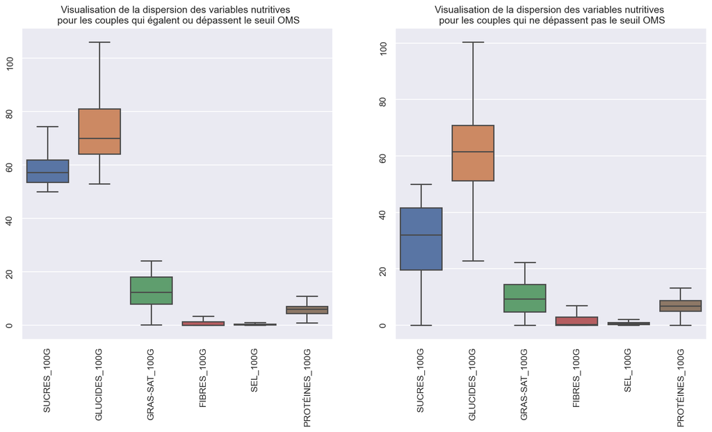

```python
sns.set()
fig, ax = plt.subplots(1, 2,figsize=(15,7),dpi =150)

df_oms_plus = df_SNACK.loc[(df_SNACK['SUCRES_100G']>= 50),var_quant_100]
df_oms_moins = df_SNACK.loc[(df_SNACK['SUCRES_100G']< 50),var_quant_100]

sns.boxplot(data = df_oms_plus, orient ='v', ax = ax[0],showfliers=False)
ax[0].tick_params(labelrotation = 90)
ax[0].set_title('Visualisation de la dispersion des variables nutritives \n pour les couples qui égalent ou dépassent le seuil OMS')

sns.boxplot(data = df_oms_moins , orient ='v',ax = ax[1],showfliers=False)
ax[1].tick_params(labelrotation = 90)
ax[1].set_title('Visualisation de la dispersion des variables nutritives \n pour les couples qui ne dépassent pas le seuil OMS')

plt.savefig('P3_N2_21a.png',dpi = 150,bbox_inches = 'tight')
```

```python
df_oms_plus = df_SNACK.loc[(df_SNACK['SUCRES_100G']>= 50),:]
df_oms_moins = df_SNACK.loc[(df_SNACK['SUCRES_100G']< 50),:]
```

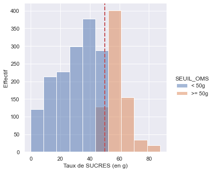

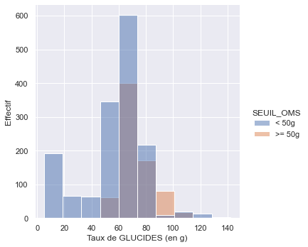

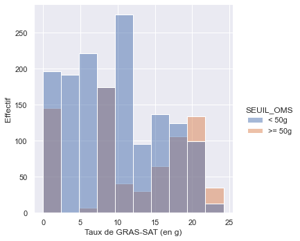

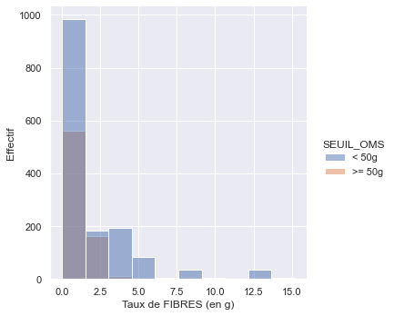

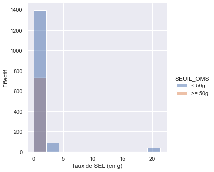

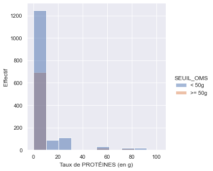

```python
for i, vvar in enumerate(var_quant_100):
    if vvar == 'SUCRES_100G':
        g = sns.displot(df_SNACK, x= vvar, bins = 10, kind = 'hist', height = 5, aspect =1.,
                       hue = 'SEUIL_OMS')
        plt.axvline(50,linewidth=2, color='r', ls = '--')
        g.set_xlabels('Taux de'+' '+str(vvar)[:-5]+' (en g)')
        g.set_ylabels('Effectif')
        #plt.title('Distribution de la valeur nutritive \n'+str(vvar)[:-5]+' pour un couple (boissons ; sucreries) \n Taux de sucre >= 50g')
        plt.savefig('P3_N2_21b'+str(i)+'.png',dpi = 150,bbox_inches = 'tight')
    else :
        g = sns.displot(df_SNACK, x= vvar, bins = 10, kind = 'hist', height = 5, aspect =1.,
                         hue = 'SEUIL_OMS')
        g.set_xlabels('Taux de'+' '+str(vvar)[:-5]+' (en g)')
        g.set_ylabels('Effectif')
        #plt.title('Distribution de la valeur nutritive \n'+str(vvar)[:-5]+' pour un couple (boissons ; sucreries)\n Taux de sucre >= 50g')
        plt.savefig('P3_N2_21b'+str(i)+'.png',dpi = 150,bbox_inches = 'tight')
```

- ## Le nombre d'additifs

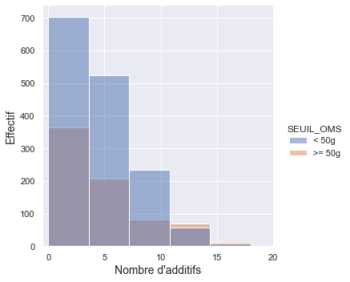

```python
g = sns.displot(df_SNACK, x = 'NB_ADDITIFS', kind = 'hist', hue = 'SEUIL_OMS',
                height=5, aspect = 1, bins = 5)
g.set(xlim=(-0.5,20))#, #Set the limit and ticks of the x-and y-axis
          #ylim=(0,1))
g.set_ylabels('Effectif', fontsize = 14)
g.set_xlabels('Nombre d\'additifs', fontsize = 14)
plt.savefig('P3_N2_21d.png',dpi = 150,bbox_inches = 'tight')
```

- ## Variable d'énergie

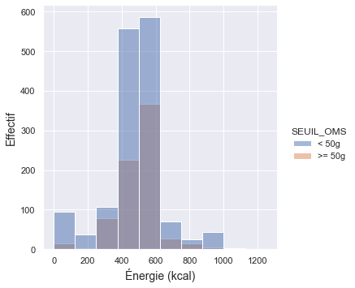

```python
g = sns.displot(df_SNACK, x = 'ENERGIE-KCAL_100G', kind = 'hist', hue = 'SEUIL_OMS',
                height=5, aspect = 1, bins = 10)
#g.set(xlim=(-0.5,20))#, #Set the limit and ticks of the x-and y-axis
          #ylim=(0,1))
g.set_ylabels('Effectif', fontsize = 14)
g.set_xlabels('Énergie (kcal)', fontsize = 14)
plt.savefig('P3_N2_21e.png',dpi = 150,bbox_inches = 'tight')
```

## 2.2 Variables catégorielles

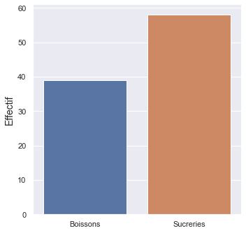

```python
g = sns.catplot(data = df_SL, x = 'catégorie', kind = 'count',height=5, aspect = 1)
g.set_ylabels('Effectif', fontsize = 14)
g.set_xlabels('', fontsize = 14)
plt.savefig('P3_N2_22a.png',dpi = 150,bbox_inches = 'tight')
```

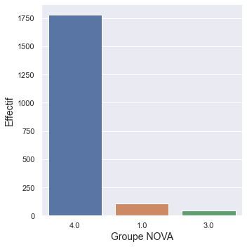

```python
order_= df_SNACK['NOVA_GROUP'].value_counts().index
g = sns.catplot(data = df_SNACK, x = 'NOVA_GROUP', kind = 'count',height=5, aspect = 1,
                order =order_)
g.set_ylabels('Effectif', fontsize = 14)
g.set_xlabels('Groupe NOVA', fontsize = 14)
#plt.title('Boissons')
plt.savefig('P3_N2_22b_x.png',dpi = 150,bbox_inches = 'tight')
```

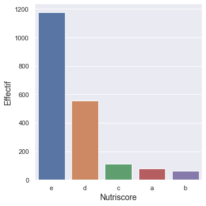

```python
order_= df_SNACK['NUTRISCORE_GRADE'].value_counts().index
g = sns.catplot(data = df_SNACK, x = 'NUTRISCORE_GRADE', kind = 'count',height=5, aspect = 1,
                order =order_)
g.set_ylabels('Effectif', fontsize = 14)
g.set_xlabels('Nutriscore', fontsize = 14)
plt.savefig('P3_N2_22c_x.png',dpi = 150,bbox_inches = 'tight')
```

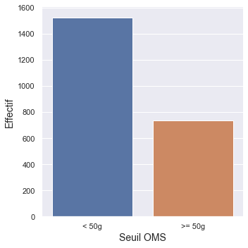

```python
order_= df_SNACK['SEUIL_OMS'].value_counts().index
g = sns.catplot(data = df_SNACK, x = 'SEUIL_OMS', kind = 'count',height=5, aspect = 1,
                order =order_)
g.set_ylabels('Effectif', fontsize = 14)
g.set_xlabels('Seuil OMS', fontsize = 14)
plt.title('')
plt.savefig('P3_N2_22d.png',dpi = 150,bbox_inches = 'tight')
```

# 3. Analyses bivariées

## 3.1 Variables quantitatives vs variables quantitatives

```python
var_quant = ['SUCRES_100G', 'GLUCIDES_100G',
       'GRAS-SAT_100G', 'FIBRES_100G', 'SEL_100G', 'PROTÉINES_100G',
       'NB_ADDITIFS', 'ENERGIE-KCAL_100G']
corr = df_SNACK[var_quant].corr()
corr
```

|  | SUCRES_100G | GLUCIDES_100G | GRAS-SAT_100G | FIBRES_100G | SEL_100G | PROTÉINES_100G | NB_ADDITIFS | ENERGIE-KCAL_100G |
| --- | --- | --- | --- | --- | --- | --- | --- | --- |
| SUCRES_100G | 1.000000 | 0.585228 | 0.392364 | -0.192465 | -0.318714 | -0.091356 | 0.052080 | 0.169971 |
| GLUCIDES_100G | 0.585228 | 1.000000 | 0.100839 | -0.065251 | -0.040472 | -0.101091 | 0.070050 | 0.194767 |
| GRAS-SAT_100G | 0.392364 | 0.100839 | 1.000000 | -0.041506 | -0.152172 | 0.083792 | -0.125386 | 0.369126 |
| FIBRES_100G | -0.192465 | -0.065251 | -0.041506 | 1.000000 | 0.420975 | 0.116580 | -0.068290 | 0.067552 |
| SEL_100G | -0.318714 | -0.040472 | -0.152172 | 0.420975 | 1.000000 | 0.086832 | -0.057218 | 0.023248 |
| PROTÉINES_100G | -0.091356 | -0.101091 | 0.083792 | 0.116580 | 0.086832 | 1.000000 | -0.014598 | 0.352051 |
| NB_ADDITIFS | 0.052080 | 0.070050 | -0.125386 | -0.068290 | -0.057218 | -0.014598 | 1.000000 | -0.087119 |
| ENERGIE-KCAL_100G | 0.169971 | 0.194767 | 0.369126 | 0.067552 | 0.023248 | 0.352051 | -0.087119 | 1.000000 |

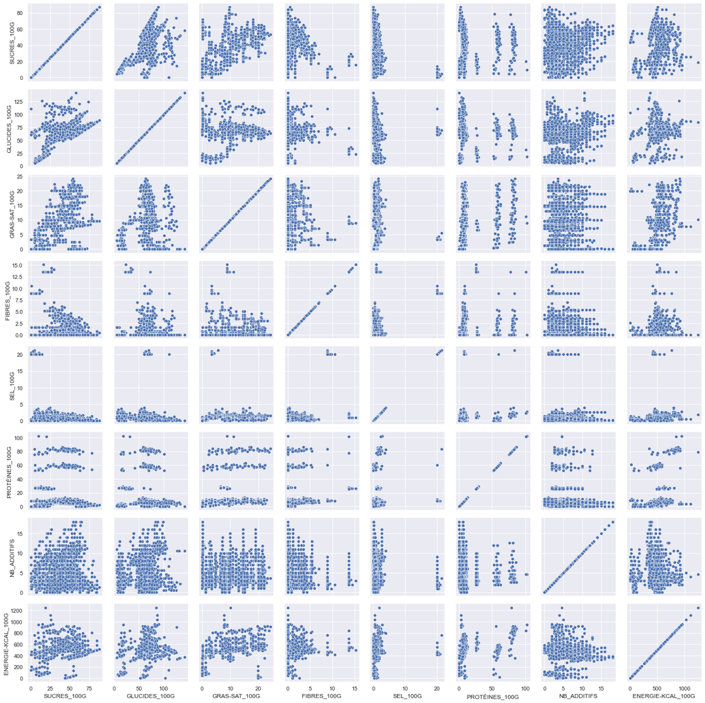

```python
g = sns.PairGrid(df_SNACK[var_quant])
g.map(sns.scatterplot)
plt.savefig('P3_N2_31a.png', dpi = 200)
```

```python
var
```

```
Index(['SUCRES_100G', 'GRAS-SAT_100G', 'FIBRES_100G', 'SEL_100G',
       'NB_ADDITIFS', 'ENERGIE-KCAL_100G', 'GLUCIDES_100G', 'PROTÉINES_100G',
       'NOVA_GROUP', 'NUTRISCORE_GRADE'],
      dtype='object')
```

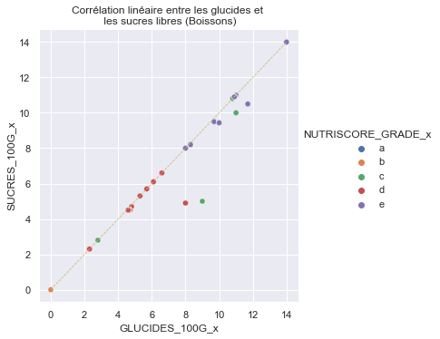

```python
## PLOT SUGAR VS CARBONHYDRATES

g = sns.relplot(data = df_SNACK, y ='SUCRES_100G_x',
                x = 'GLUCIDES_100G_x', hue = 'NUTRISCORE_GRADE_x', hue_order = ['a','b','c','d','e'],
                alpha = 0.5
        )
plt.plot([0,14], [0, 14], 'y-', label='line 1', linewidth=0.8,ls = '--')
plt.title("Corrélation linéaire entre les glucides et \n les sucres libres (Boissons)")
plt.savefig("P3_N2_31bx.png",dpi=150,bbox_inches = 'tight')
```

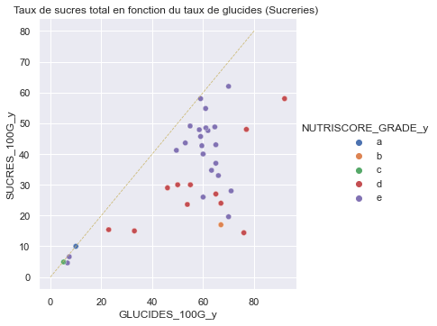

```python
## PLOT SUGAR VS CARBONHYDRATES

g = sns.relplot(data = df_SNACK, y ='SUCRES_100G_y',
                x = 'GLUCIDES_100G_y', hue = 'NUTRISCORE_GRADE_y', hue_order = ['a','b','c','d','e'],
                alpha = 0.5
        )
plt.plot([0,80], [0, 80], 'y-', label='line 1', linewidth=0.8,ls = '--')
plt.title("Taux de sucres total en fonction du taux de glucides (Sucreries) ")
plt.savefig("P3_N2_31by.png",dpi=150,bbox_inches = 'tight')
```

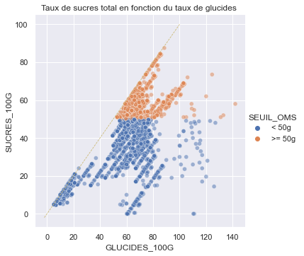

```python
## PLOT SUGAR VS CARBONHYDRATES

g = sns.relplot(data = df_SNACK, y ='SUCRES_100G',
                x = 'GLUCIDES_100G', hue = 'SEUIL_OMS', alpha = 0.5
        )
plt.plot([-2,100], [-2, 100], 'y-', label='line 1', linewidth=0.8,ls = '--')
plt.title("Taux de sucres total en fonction du taux de glucides ")
plt.savefig("P3_N2_31c.png",dpi=150,bbox_inches = 'tight')
```

## 3.2 Variables qualitatives vs variables qualitatives

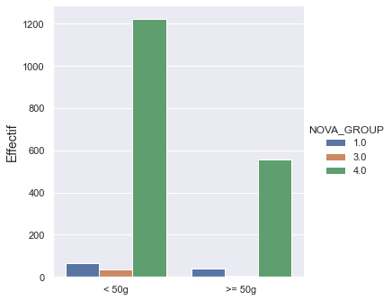

```python
g = sns.catplot(data = df_SNACK, x = 'SEUIL_OMS', kind = 'count',height=5, aspect = 1, hue = 'NOVA_GROUP')
g.set_ylabels('Effectif', fontsize = 14)
g.set_xlabels('', fontsize = 14)
plt.savefig('P3_N2_32a.png',dpi = 150,bbox_inches = 'tight')
```

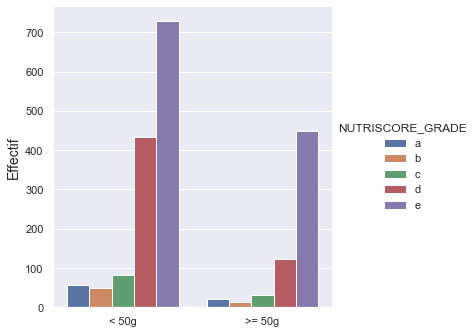

```python
g = sns.catplot(data = df_SNACK, x = 'SEUIL_OMS', kind = 'count',height=5, aspect = 1, hue = 'NUTRISCORE_GRADE',
               hue_order = ['a','b','c','d','e'])
g.set_ylabels('Effectif', fontsize = 14)
g.set_xlabels('', fontsize = 14)
plt.savefig('P3_N2_32b.png',dpi = 150,bbox_inches = 'tight')
```

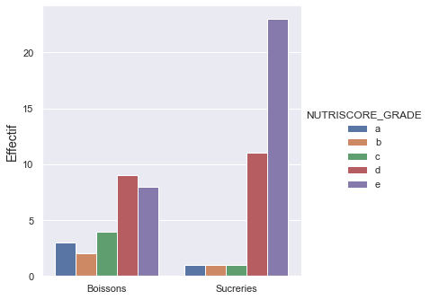

```python
g = sns.catplot(data = df_SL, x = 'catégorie', kind = 'count',height=5, aspect = 1, hue = 'NUTRISCORE_GRADE',
               hue_order = ['a','b','c','d','e'])
g.set_ylabels('Effectif', fontsize = 14)
g.set_xlabels('', fontsize = 14)
plt.savefig('P3_N2_32c.png',dpi = 150,bbox_inches = 'tight')
```

```python
df_SNACK.loc[(df_SNACK['NUTRISCORE_GRADE']=='a') & (df_SNACK['SEUIL_OMS']=='>= 50g')]
```

|  | Boissons | Sucreries | SUCRES_100G | GLUCIDES_100G | GRAS-SAT_100G | FIBRES_100G | SEL_100G | PROTÉINES_100G | NB_ADDITIFS | ENERGIE-KCAL_100G | SEUIL_OMS | NOVA_GROUP | NUTRISCORE_GRADE |
| --- | --- | --- | --- | --- | --- | --- | --- | --- | --- | --- | --- | --- | --- |
| 2 | CRISTALINE | M M S CRIPSY | 55.5 | 59.2 | 18.0 | 0.000000 | 0.202 | 6.0 | 1.038543 | 535.0 | >= 50g | 1.0 | a |
| 3 | CRISTALINE | COTE D'OR NOISETTES - | 73.5 | 74.5 | 9.6 | 0.000000 | 0.110 | 1.9 | 0.000000 | 455.0 | >= 50g | 1.0 | a |
| 10 | CRISTALINE | SNICKERS - | 52.0 | 61.0 | 7.9 | 0.000000 | 0.730 | 8.6 | 0.200000 | 481.0 | >= 50g | 1.0 | a |
| 18 | CRISTALINE | MILKA COOKIES | 51.0 | 55.0 | 20.0 | 1.400000 | 0.600 | 5.2 | 1.000000 | 560.0 | >= 50g | 1.0 | a |
| 33 | CRISTALINE | HARIBO HAPPY LIFE | 52.0 | 83.0 | 0.1 | 0.000000 | 0.130 | 4.1 | 1.600000 | 352.0 | >= 50g | 1.0 | a |
| ... | ... | ... | ... | ... | ... | ... | ... | ... | ... | ... | ... | ... | ... |
| 2156 | COCA COLA S\/SUCRE | SNICKERS - | 62.9 | 71.9 | 7.9 | 0.175911 | 0.650 | 8.6 | 1.162288 | 520.0 | >= 50g | NaN | a |
| 2164 | COCA COLA S\/SUCRE | MILKA COOKIES | 61.9 | 65.9 | 20.0 | 1.575911 | 0.520 | 5.2 | 1.962288 | 599.0 | >= 50g | NaN | a |
| 2179 | COCA COLA S\/SUCRE | HARIBO HAPPY LIFE | 62.9 | 93.9 | 0.1 | 0.175911 | 0.050 | 4.1 | 2.562288 | 391.0 | >= 50g | NaN | a |
| 2181 | COCA COLA S\/SUCRE | HARIBO CROCO HARIBO | 61.9 | 91.9 | 0.1 | 0.175911 | 0.190 | 6.0 | 10.962288 | 393.0 | >= 50g | NaN | a |
| 2195 | COCA COLA S\/SUCRE | NAPOLITAIN CLASSIQUE | 61.9 | 63.9 | 21.0 | 3.175911 | 0.170 | 6.0 | 1.962288 | 605.0 | >= 50g | 4.0 | a |

120 rows × 13 columns

[output not shown]

## 3.3 Variables quantitatives vs variables qualitatives

```python
def eta_squared(x,y):
    #x, variable qualitative
    #y, variable quantitative
    moyenne_y = y.mean(skipna = True)
    #print(moyenne_y)
    classes = []
    for classe in x.unique():
        #print(classe)
        yi_classe = y[x==classe] #yi_classe, vecteur comprenant l'ensemble des composante de la classe
        #print(yi_classe)
        if len(yi_classe) == 0:
            print(classe,'ni = ',0)
        else:
            classes.append({'ni': len(yi_classe), #ajout d'un dictionnaire pour chaque classe, comprenant la longueur et la moy.
                        'moyenne_classe': yi_classe.mean(skipna = True)})
    #print(classes)
    SCT = sum([(yj-moyenne_y)**2 for yj in y]) #variance totale
    SCE = sum([c['ni']*(c['moyenne_classe']-moyenne_y)**2 for c in classes]) #variance interclasse
    return SCE/SCT
```

```python
#ANOVA
x = df_SL['catégorie']
y = df_SL['SUCRES_100G']
eta_squared(x,y)
```

```
0.5156440219897239
```

```python
#ANOVA
x = df_SL['catégorie']
y = df_SL['ENERGIE-KCAL_100G']
eta_squared(x,y)
```

```
0.7584634070810475
```

```python
#ANOVA
x = df_SNACK['SEUIL_OMS']
y = df_SNACK['SUCRES_100G']
eta_squared(x,y)
```

```
0.5610201825991152
```

```python
#ANOVA
x = df_SNACK['SEUIL_OMS']
y = df_SNACK['ENERGIE-KCAL_100G']
eta_squared(x,y)
```

```
0.002967725907350646
```

```python
#ANOVA
x = df_SNACK['SEUIL_OMS']
y = df_SNACK['PROTÉINES_100G']
eta_squared(x,y)
```

```
0.004202673551335457
```

```python
#ANOVA
x = df_SNACK['SEUIL_OMS']
y = df_SNACK['NB_ADDITIFS']
eta_squared(x,y)
```

```
0.001125875443404941
```

```python
#ANOVA
x = df_SL['catégorie']
y = df_SL['NB_ADDITIFS']
eta_squared(x,y)
```

```
0.01532447143489052
```

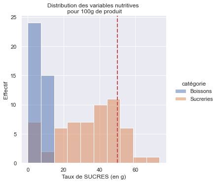

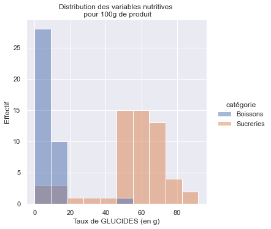

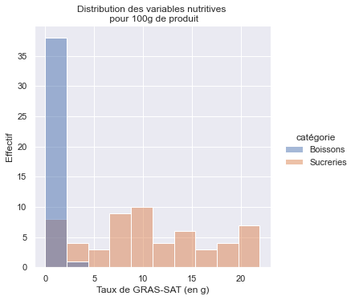

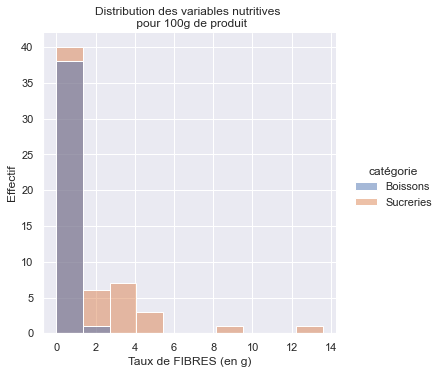

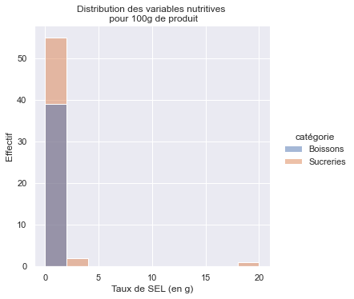

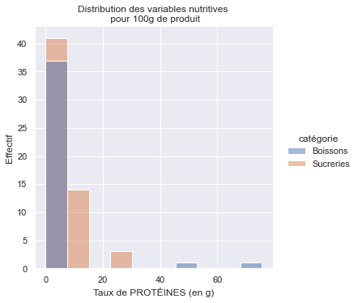

```python
for i, vvar in enumerate(var_quant_100):
    if vvar == 'SUCRES_100G':
        g = sns.displot(df_SL, x= vvar, bins = 10, kind = 'hist', height = 5, aspect =1.,hue = 'catégorie')
        plt.axvline(50,linewidth=2, color='r', ls = '--')
        g.set_xlabels('Taux de'+' '+str(vvar)[:-5]+' (en g)')
        g.set_ylabels('Effectif')
        plt.title('Distribution des variables nutritives \n pour 100g de produit')
        plt.savefig('P3_N2_33a'+str(i)+'.png',dpi = 150,bbox_inches = 'tight')
    else :
        g = sns.displot(df_SL, x= vvar, bins = 10, kind = 'hist', height = 5, aspect =1.,hue = 'catégorie')
        g.set_xlabels('Taux de'+' '+str(vvar)[:-5]+' (en g)')
        g.set_ylabels('Effectif')
        plt.title('Distribution des variables nutritives \n pour 100g de produit')
        plt.savefig('P3_N2_33a'+str(i)+'.png',dpi = 150,bbox_inches = 'tight')
```

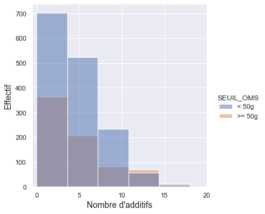

```python
g = sns.displot(df_SNACK, x = 'NB_ADDITIFS', kind = 'hist',
                height=5, aspect = 1, bins = 5, hue = 'SEUIL_OMS')
g.set(xlim=(-0.5,20))#, #Set the limit and ticks of the x-and y-axis
          #ylim=(0,1))
g.set_ylabels('Effectif', fontsize = 14)
g.set_xlabels('Nombre d\'additifs', fontsize = 14)
plt.savefig('P3_N2_33b.png',dpi = 150,bbox_inches = 'tight')
```

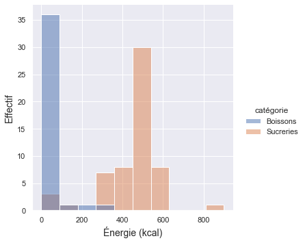

```python
g = sns.displot(df_SL, x = 'ENERGIE-KCAL_100G', kind = 'hist',
                height=5, aspect = 1, bins = 10, hue = 'catégorie')
#g.set(xlim=(-0.5,20))#, #Set the limit and ticks of the x-and y-axis
          #ylim=(0,1))
g.set_ylabels('Effectif', fontsize = 14)
g.set_xlabels('Énergie (kcal)', fontsize = 14)
plt.savefig('P3_N2_33c.png',dpi = 150,bbox_inches = 'tight')
```

# 4. Analyses multivariées

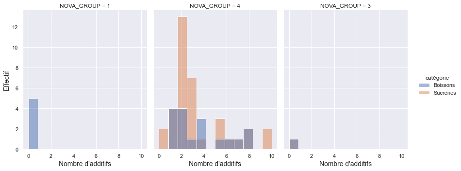

```python
g = sns.displot(df_SL, x = 'NB_ADDITIFS', kind = 'hist', col = 'NOVA_GROUP',
                height=5, aspect = 0.8, bins = 12 , hue = 'catégorie')
#g.set(xlim=(-0.5,10))#, #Set the limit and ticks of the x-and y-axis
          #ylim=(0,1))
g.set_ylabels('Effectif', fontsize = 14)
g.set_xlabels('Nombre d\'additifs', fontsize = 14)
plt.savefig('P3_N2_33d.png',dpi = 150,bbox_inches = 'tight')
```

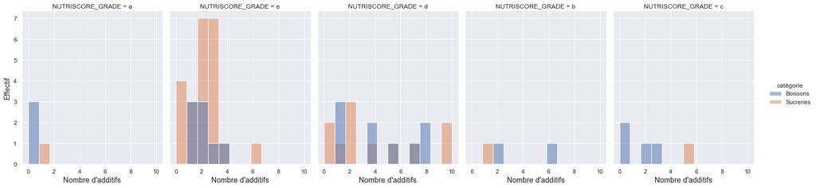

```python
g = sns.displot(df_SL, x = 'NB_ADDITIFS', kind = 'hist', col = 'NUTRISCORE_GRADE',hue = 'catégorie',
                height=5, aspect = 0.8, bins = 12)
#g.set(xlim=(-0.5,10))#, #Set the limit and ticks of the x-and y-axis
          #ylim=(0,1))
g.set_ylabels('Effectif', fontsize = 14)
g.set_xlabels('Nombre d\'additifs', fontsize = 14)
plt.savefig('P3_N2_33e.png',dpi = 150,bbox_inches = 'tight')
```